# NLP_Project_Full_Code-JRW

## **Word Embeddings**

### Word2Vec

```python
# Creating a list of all words in our data
wordslist = [item.split(" ") for item in stock['News'].values]
```

```python
# Creating an instance of Word2Vec
vec_size = 300
model_W2V = Word2Vec(wordslist, vector_size = vec_size, min_count = 1, window=5, workers = 6)
```

```python
# Checking the size of the vocabulary
print("Length of the words list is", len(list(model_W2V.wv.key_to_index)))
```

```
Length of the words list is 4682
```

Let's check out a few word embeddings obtained using the model.

```python
# Checking the word embedding of a random word
word = "earnings"
model_W2V.wv[word]
```

[output not shown]

```python
# Checking the word embedding of a random word
word = "losses"
model_W2V.wv[word]
```

[output not shown]

[output cut: 21 more lines]

```
       -8.10175494e-04, -1.85623709e-02,  1.02410580e-04,  3.74757196e-03,
        3.45228170e-03,  1.34144034e-02,  3.14418809e-03,  1.96519215e-03,
        7.86856376e-03, -5.22205839e-03, -1.96760446e-02, -1.19665759e-02,
        1.97106861e-02,  6.52331905e-03, -2.14703046e-02, -1.53456703e-02,
        9.41481255e-03,  2.56970699e-04,  9.91178676e-03, -2.09872779e-02,
       -2.11435705e-02,  3.12527549e-03,  1.20608900e-02,  1.12724993e-02,
       -2.04990972e-02,  3.25401942e-03, -3.30543169e-03,  4.90037305e-03,
        4.93826531e-03,  8.81941349e-04,  1.57214571e-02,  5.97257167e-03,
        1.28971031e-02,  5.40686364e-04, -1.45478817e-02,  3.37440078e-03,
        1.05267912e-02, -9.20465623e-04, -2.81938817e-03,  4.69336146e-03,
       -7.03640794e-03,  7.94878637e-04, -1.98247526e-02,  8.40413198e-03,
       -5.25781419e-04,  1.33945644e-02,  5.94449462e-03,  1.85819026e-02,
        1.23275500e-02, -2.83279270e-03,  1.62280854e-02,  2.43710857e-02,
       -2.23245923e-04, -9.19843931e-03,  1.40783628e-02, -1.03658950e-02],
      dtype=float32)
```

```python
# Retrieves the words present in the Word2Vec model's vocabulary, the word vectors for all the words present in the model's vocabulary
# And then creates a dictionary of words and corresponding vectors for those words
words = list(model_W2V.wv.key_to_index.keys())
wvs = model_W2V.wv[words].tolist()
word_vector_dict = dict(zip(words, wvs))
```

```python
def average_vectorizer_Word2Vec(doc):
    # Initializing a feature vector for the sentence
    feature_vector = np.zeros((vec_size,), dtype="float64")

    # Creating a list of words in the sentence that are present in the model vocabulary
    words_in_vocab = [word for word in doc.split() if word in words]

    # adding the vector representations of the words
    for word in words_in_vocab:
        feature_vector += np.array(word_vector_dict[word])

    # Dividing by the number of words to get the average vector
    if len(words_in_vocab) != 0:
        feature_vector /= len(words_in_vocab)

    return feature_vector
```

```python
# creating a dataframe of the vectorized documents
start = time.time()

X_train_wv = pd.DataFrame(X_train["News"].apply(average_vectorizer_Word2Vec).tolist(), columns=['Feature '+str(i) for i in range(vec_size)])
X_val_wv = pd.DataFrame(X_val["News"].apply(average_vectorizer_Word2Vec).tolist(), columns=['Feature '+str(i) for i in range(vec_size)])
X_test_wv = pd.DataFrame(X_test["News"].apply(average_vectorizer_Word2Vec).tolist(), columns=['Feature '+str(i) for i in range(vec_size)])

end = time.time()

print('Time taken ', (end-start))
```

```
Time taken  0.3439617156982422
```

```python
print(X_train_wv.shape, X_val_wv.shape, X_test_wv.shape)
```

```
(286, 300) (21, 300) (42, 300)
```

### GloVe

```python
# # Download the GloVe embeddings if not present
# !wget http://nlp.stanford.edu/data/glove.6B.zip
# !unzip glove.6B.zip

# Converting the Stanford GloVe model vector format to word2vec
filename = '/content/drive/My Drive/ColabNotebooks/glove.6B.100d.txt.word2vec'
from gensim.models import KeyedVectors
# load the Stanford GloVe model
glove_model = KeyedVectors.load_word2vec_format(filename, binary=False)
```

```python
# Checking the size of the vocabulary
print("Length of the vocabulary is", len(glove_model.index_to_key))
```

```
Length of the vocabulary is 400000
```

Let's check out a few word embeddings.

```python
# Checking the word embedding of a random word
word = "earnings"
glove_model[word]
```

```
array([ 2.3659e-02,  1.1938e-01,  5.0490e-01, -2.9026e-01,  3.5383e-02,
       -1.2851e+00, -2.8019e-02, -4.9495e-01, -9.5245e-01, -3.9641e-01,
        4.8578e-01,  5.1052e-01,  6.4173e-01, -5.8002e-01,  1.3649e-01,
       -3.8810e-01, -8.2228e-01,  2.3633e-01,  9.5612e-01,  8.6964e-01,
        5.9079e-01, -4.7911e-01, -3.0110e-01,  2.3779e+00, -9.0503e-01,
       -2.3864e-01,  1.2921e-01, -1.9986e-01, -7.9080e-01, -5.3609e-01,
        6.6792e-01,  3.9620e-02, -9.3801e-01, -6.6053e-01, -3.6257e-01,
        3.4303e-01,  3.6001e-02,  3.3055e-01,  5.5457e-02, -3.5244e-01,
        2.5275e-01, -7.9959e-01, -6.5225e-01,  3.9641e-01, -2.8247e-01,
        8.1491e-02,  7.7405e-02, -5.8692e-01, -1.3553e-01, -2.4162e+00,
       -1.5092e-02, -2.1763e-02,  1.1769e-01,  4.8020e-01,  5.3548e-02,
       -1.8296e+00, -1.7302e-01, -2.0599e-01,  1.6853e+00, -1.4020e-01,
       -3.2904e-01, -4.5978e-01, -1.0213e+00,  1.6796e-02, -1.0600e+00,
       -3.5544e-01,  1.1922e-01,  1.1121e-01,  8.8164e-01, -2.1342e-01,
        5.7217e-03,  5.9016e-01, -3.0873e-01, -3.3313e-01, -1.8984e-03,
        7.9190e-02,  3.7642e-01, -3.9996e-01, -4.0221e-01,  8.2269e-02,
        6.5266e-01,  4.3169e-01, -5.8269e-01,  2.8100e-01, -1.1744e+00,
       -1.5854e+00, -1.1282e-01, -1.1009e+00,  1.4616e-01,  2.2278e-02,
       -3.5740e-01,  3.7117e-01, -3.2464e-01, -7.1684e-01, -6.8993e-01,
        1.4540e-01,  9.4609e-01, -1.8060e-01,  6.5868e-01,  3.6235e-01],
      dtype=float32)
```

```python
# Checking the word embedding of a random word
word = "losses"
glove_model[word]
```

```
array([-0.15123 ,  0.41693 ,  0.21006 , -0.14063 , -0.5893  , -0.8064  ,
       -0.2591  , -0.46898 , -0.54736 , -0.31746 ,  0.55043 ,  0.40922 ,
        0.025984, -0.14648 , -0.055148, -0.14035 , -1.0188  , -0.21538 ,
        0.262   ,  0.56175 ,  1.039   ,  0.17718 , -0.68095 ,  1.2231  ,
       -0.38251 , -0.59891 , -0.20719 ,  0.25834 , -0.28959 , -0.65156 ,
        0.37852 , -0.43138 , -0.67446 , -0.33975 , -0.88331 , -0.5415  ,
        0.20083 , -0.13791 , -0.64534 ,  0.07895 ,  0.59418 , -1.1282  ,
       -0.36491 , -0.036948,  0.26923 ,  0.021281,  0.86301 , -0.08751 ,
       -0.16334 , -1.2303  , -0.42988 ,  0.11454 ,  0.39975 ,  0.84938 ,
        0.81922 , -1.3082  ,  0.47153 , -0.74057 ,  1.6471  ,  1.2265  ,
       -0.63239 ,  0.16757 , -0.69451 ,  0.44465 ,  0.04122 , -0.037105,
        0.20498 , -0.11224 ,  0.82731 ,  0.024071, -0.5587  ,  0.078656,
       -0.89373 ,  0.071249,  0.27008 , -0.22393 , -0.50032 ,  0.59582 ,
       -1.1767  ,  1.2932  ,  1.3619  ,  0.10454 , -0.608   ,  0.19416 ,
       -1.2338  , -1.1957  , -0.47178 , -0.56717 ,  0.11016 ,  0.30762 ,
       -0.56996 , -0.15471 , -0.1694  , -0.071958, -0.30753 ,  0.31186 ,
        0.92477 ,  0.38211 ,  0.78787 , -0.75038 ], dtype=float32)
```

```python
# Retrieving the words present in the GloVe model's vocabulary
glove_words = glove_model.index_to_key

# Creating a dictionary of words and their corresponding vectors
glove_word_vector_dict = dict(zip(glove_model.index_to_key,list(glove_model.vectors)))
```

```python
vec_size=100
```

```python
def average_vectorizer_GloVe(doc):
    # Initializing a feature vector for the sentence
    feature_vector = np.zeros((vec_size,), dtype="float64")

    # Creating a list of words in the sentence that are present in the model vocabulary
    words_in_vocab = [word for word in doc.split() if word in glove_words]

    # adding the vector representations of the words
    for word in words_in_vocab:
        feature_vector += np.array(glove_word_vector_dict[word])

    # Dividing by the number of words to get the average vector
    if len(words_in_vocab) != 0:
        feature_vector /= len(words_in_vocab)

    return feature_vector
```

```python
# creating a dataframe of the vectorized documents
start = time.time()

X_train_gl = pd.DataFrame(X_train["News"].apply(average_vectorizer_GloVe).tolist(), columns=['Feature '+str(i) for i in range(vec_size)])
X_val_gl = pd.DataFrame(X_val["News"].apply(average_vectorizer_GloVe).tolist(), columns=['Feature '+str(i) for i in range(vec_size)])
X_test_gl = pd.DataFrame(X_test["News"].apply(average_vectorizer_GloVe).tolist(), columns=['Feature '+str(i) for i in range(vec_size)])

end = time.time()
print('Time taken ', (end-start))
```

```
Time taken  14.167967319488525
```

```python
print(X_train_gl.shape, X_val_gl.shape, X_test_gl.shape)
```

```
(286, 100) (21, 100) (42, 100)
```

### Sentence Transformer

#### Defining the model

```python
#Defining the model
model = SentenceTransformer('sentence-transformers/all-MiniLM-L6-v2')
```

#### Encoding the dataset

```python
# setting the device to GPU if available, else CPU
device = torch.device("cuda" if torch.cuda.is_available() else "cpu")
```

```python
# encoding the dataset
start = time.time()

X_train_st = model.encode(X_train["News"].values, show_progress_bar=True, device=device)
X_val_st = model.encode(X_val["News"].values, show_progress_bar=True, device=device)
X_test_st = model.encode(X_test["News"].values, show_progress_bar=True, device=device)

end = time.time()
print("Time taken ",(end-start))
```

```
Time taken  1.479187250137329
```

```python
print(X_train_st.shape, X_val_st.shape, X_test_st.shape)
```

```
(286, 384) (21, 384) (42, 384)
```

- Each news content has been converted to a 384-dimensional vector.

## **Sentiment Analysis**

### Model Evaluation Criterion

- Evaluation Criteria will be based on accuracy secondarily and F1 score primarily.
- Goal is to the balance between precision and recall, captured by the F1 score is also important due to the fact there are multiple output classes/labels to be balanced between
- Also ensure the highest accuracy possible of correctly predicting sentiment, whether positive, neutral, or negative

### Utility Functions

```python
def plot_confusion_matrix(model, predictors, target):
    """
    Plot a confusion matrix to visualize the performance of a classification model.

    Parameters:
    actual (array-like): The true labels.
    predicted (array-like): The predicted labels from the model.

    Returns:
    None: Displays the confusion matrix plot.
    """
    pred = model.predict(predictors)  # Make predictions using the classifier.

    cm = confusion_matrix(target, pred)  # Compute the confusion matrix.

    plt.figure(figsize=(5, 4))  # Create a new figure with a specified size.
    label_list = [0, 1,-1]  # Define the labels for the confusion matrix.
    sns.heatmap(cm, annot=True, fmt='.0f', cmap='Blues', xticklabels=label_list, yticklabels=label_list)
    # Plot the confusion matrix using a heatmap with annotations.

    plt.ylabel('Actual')  # Label for the y-axis.
    plt.xlabel('Predicted')  # Label for the x-axis.
    plt.title('Confusion Matrix')  # Title of the plot.
    plt.show()  # Display the plot.
```

```python
def model_performance_classification_sklearn(model, predictors, target):
    """
    Compute various performance metrics for a classification model using sklearn.

    Parameters:
    model (sklearn classifier): The classification model to evaluate.
    predictors (array-like): The independent variables used for predictions.
    target (array-like): The true labels for the dependent variable.

    Returns:
    pandas.DataFrame: A DataFrame containing the computed metrics (Accuracy, Recall, Precision, F1-score).
    """
    pred = model.predict(predictors)  # Make predictions using the classifier.

    acc = accuracy_score(target, pred)  # Compute Accuracy.
    recall = recall_score(target, pred,average='weighted')  # Compute Recall.
    precision = precision_score(target, pred,average='weighted')  # Compute Precision.
    f1 = f1_score(target, pred,average='weighted')  # Compute F1-score.

    # Create a DataFrame to store the computed metrics.
    df_perf = pd.DataFrame(
        {
            "Accuracy": [acc],
            "Recall": [recall],
            "Precision": [precision],
            "F1": [f1],
        }
    )

    return df_perf  # Return the DataFrame with the metrics.
```

## Base Models

### Base Model - Word2Vec

```python
# Building the model

base_wv = GradientBoostingClassifier(random_state = 42)

# Fitting on train data
base_wv.fit(X_train_wv, y_train)
```

```
GradientBoostingClassifier(random_state=42)
```

```python
plot_confusion_matrix(base_wv,X_train_wv,y_train)
```

[output not shown]

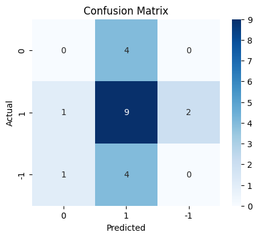

```python
plot_confusion_matrix(base_wv,X_val_wv,y_val)
```

```python
#Calculating different metrics on training data
base_train_wv = model_performance_classification_sklearn(base_wv,X_train_wv,y_train)
print("Training performance:\n", base_train_wv)
```

```
Training performance:
    Accuracy  Recall  Precision   F1
0       1.0     1.0        1.0  1.0
```

```python
#Calculating different metrics on validation data
base_val_wv = model_performance_classification_sklearn(base_wv,X_val_wv,y_val)
print("Validation performance:\n",base_val_wv)
```

```
Validation performance:
    Accuracy    Recall  Precision       F1
0  0.428571  0.428571   0.302521  0.35468
```

Observations:

- Overfit on training and poor performance on the validation

### Base Model - GloVe

```python
#Building the model

base_gl = GradientBoostingClassifier(random_state = 42)

# Fitting on train data
base_gl.fit(X_train_gl, y_train)
```

```
GradientBoostingClassifier(random_state=42)
```

```python
plot_confusion_matrix(base_gl,X_train_gl,y_train)
```

[output not shown]

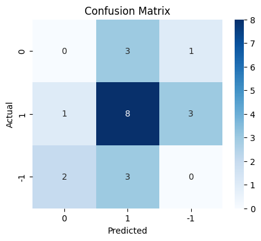

```python
plot_confusion_matrix(base_gl,X_val_gl,y_val)
```

```python
#Calculating different metrics on training data
base_train_gl=model_performance_classification_sklearn(base_gl,X_train_gl,y_train)
print("Training performance:\n", base_train_gl)
```

```
Training performance:
    Accuracy  Recall  Precision   F1
0       1.0     1.0        1.0  1.0
```

```python
#Calculating different metrics on validation data
base_val_gl = model_performance_classification_sklearn(base_gl,X_val_gl,y_val)
print("Validation performance:\n",base_val_gl)
```

```
Validation performance:
    Accuracy    Recall  Precision        F1
0  0.380952  0.380952   0.326531  0.351648
```

Observations:

- Overfit on training and poor performance on the validation

### Base Model - Sentence Transformer

```python
# Building the model

base_st = GradientBoostingClassifier(random_state = 42)

# Fitting on train data
base_st.fit(X_train_st, y_train)
```

```
GradientBoostingClassifier(random_state=42)
```

```python
plot_confusion_matrix(base_st,X_train_st,y_train)
```

[output not shown]

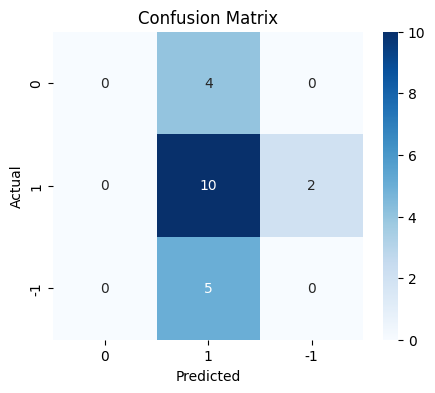

```python
plot_confusion_matrix(base_st,X_val_st,y_val)
```

```python
#Calculating different metrics on training data
base_train_st=model_performance_classification_sklearn(base_st,X_train_st,y_train)
print("Training performance:\n", base_train_st)
```

```
Training performance:
    Accuracy  Recall  Precision   F1
0       1.0     1.0        1.0  1.0
```

```python
#Calculating different metrics on validation data
base_val_st = model_performance_classification_sklearn(base_st,X_val_st,y_val)
print("Validation performance:\n",base_val_st)
```

```
Validation performance:
    Accuracy   Recall  Precision        F1
0   0.47619  0.47619   0.300752  0.368664
```

Observations:

- Overfit on training and poor performance on the validation

Observations:

- All the base models are overfitting the training data, as all performance metrics are a value of 1
- Thus it is not surprise that all the models perform very poorly on the validation data as a result. The best scores seen are by the Sentance Transformer Model, which has accuracy of 0.476 and F1 score of 0.369

## Tuned Models

### Tuned Model - Word2Vec

**Note**: The parameter grid provided below is a sample grid. It can be modified depending on the compute power of the system being used.

```python
start = time.time()

# Choose the type of classifier.

tuned_wv = GradientBoostingClassifier(random_state = 1)

parameters = {
    'max_depth': np.arange(3,9),
    'min_samples_split': np.arange(5,16,2),
    'max_features': ['log2', 'sqrt', 0.2, 0.4]
}

# Run the grid search
grid_obj = GridSearchCV(tuned_wv, parameters, scoring='f1_weighted',cv=3,n_jobs=-1)
grid_obj = grid_obj.fit(X_train_wv, y_train)

end = time.time()
print("Time taken ",(end-start))

# Set the clf to the best combination of parameters
tuned_wv = grid_obj.best_estimator_
```

```
Time taken  69.85078525543213
```

```python
# Fit the best algorithm to the data.
tuned_wv.fit(X_train_wv, y_train)
```

```
GradientBoostingClassifier(max_depth=6, max_features='sqrt',
                           min_samples_split=9, random_state=1)
```

```python
plot_confusion_matrix(tuned_wv,X_train_wv,y_train)
```

[output not shown]

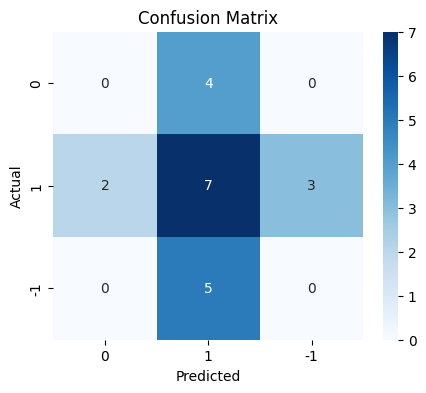

```python
plot_confusion_matrix(tuned_wv,X_val_wv,y_val)
```

```python
#Calculating different metrics on training data
tuned_train_wv=model_performance_classification_sklearn(tuned_wv,X_train_wv,y_train)
print("Training performance:\n",tuned_train_wv)
```

```
Training performance:
    Accuracy  Recall  Precision   F1
0       1.0     1.0        1.0  1.0
```

```python
#Calculating different metrics on validation data
tuned_val_wv = model_performance_classification_sklearn(tuned_wv,X_val_wv,y_val)
print("Validation performance:\n",tuned_val_wv)
```

```
Validation performance:
    Accuracy    Recall  Precision        F1
0  0.333333  0.333333       0.25  0.285714
```

Observations:

- Overfit on training stil and poor performance on the validation even after Grid Search

### Tuned Model - GloVe

```python
start = time.time()

tuned_gl = GradientBoostingClassifier(random_state = 1)

parameters = {
    'max_depth': np.arange(3,9),
    'min_samples_split': np.arange(5,16,2),
    'max_features': ['log2', 'sqrt', 0.2, 0.4]
}

# Run the grid search
grid_obj = GridSearchCV(tuned_gl, parameters, scoring='f1_weighted',cv=5,n_jobs=-1)
grid_obj = grid_obj.fit(X_train_gl, y_train)

end = time.time()
print("Time taken ",(end-start))

# Set the clf to the best combination of parameters
tuned_gl = grid_obj.best_estimator_
```

```
Time taken  37.56787323951721
```

```python
# Fit the best algorithm to the data.
tuned_gl.fit(X_train_gl, y_train)
```

```
GradientBoostingClassifier(max_depth=6, max_features='log2',
                           min_samples_split=15, random_state=1)
```

```python
plot_confusion_matrix(tuned_gl,X_train_gl,y_train)
```

[output not shown]

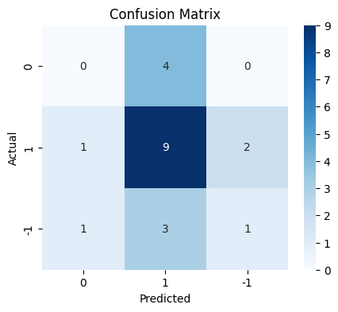

```python
plot_confusion_matrix(tuned_gl,X_val_gl,y_val)
```

```python
#Calculating different metrics on training data
tuned_train_gl=model_performance_classification_sklearn(tuned_gl,X_train_gl,y_train)
print("Training performance:\n",tuned_train_gl)
```

```
Training performance:
    Accuracy  Recall  Precision   F1
0       1.0     1.0        1.0  1.0
```

```python
#Calculating different metrics on validation data
tuned_val_gl = model_performance_classification_sklearn(tuned_gl,X_val_gl,y_val)
print("Validation performance:\n",tuned_val_gl)
```

```
Validation performance:
    Accuracy   Recall  Precision        F1
0   0.47619  0.47619   0.400794  0.426871
```

Observations:

- Overfit on training stil and poor performance on the validation even after Grid Search

### Tuned Model - Sentence Transformer

```python
start = time.time()

# Choose the type of classifier.

tuned_st = GradientBoostingClassifier(random_state = 1)

parameters = {
    'max_depth': np.arange(3,9),
    'min_samples_split': np.arange(5,16,2),
    'max_features': ['log2', 'sqrt', 0.2, 0.4]
}

# Run the grid search
grid_obj = GridSearchCV(tuned_st, parameters, scoring='f1_weighted',cv=5,n_jobs=-1)
grid_obj = grid_obj.fit(X_train_st, y_train)

end = time.time()
print("Time taken ",(end-start))

# Set the clf to the best combination of parameters
tuned_st = grid_obj.best_estimator_
```

```
Time taken  83.48331117630005
```

```python
# Fit the best algorithm to the data.
tuned_st.fit(X_train_st, y_train)
```

```
GradientBoostingClassifier(max_features='log2', min_samples_split=9,
                           random_state=1)
```

```python
plot_confusion_matrix(tuned_st,X_train_st,y_train)
```

[output not shown]

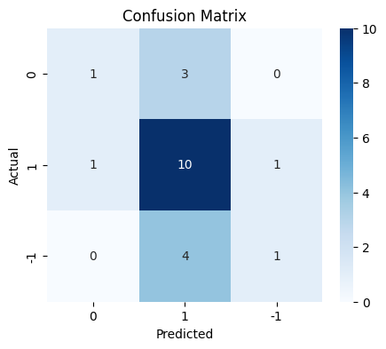

```python
plot_confusion_matrix(tuned_st,X_val_st,y_val)
```

```python
#Calculating different metrics on training data
tuned_train_st=model_performance_classification_sklearn(tuned_st,X_train_st,y_train)
print("Training performance:\n",tuned_train_st)
```

```
Training performance:
    Accuracy  Recall  Precision   F1
0       1.0     1.0        1.0  1.0
```

```python
#Calculating different metrics on validation data
tuned_val_st = model_performance_classification_sklearn(tuned_st,X_val_st,y_val)
print("Validation performance:\n",tuned_val_st)
```

```
Validation performance:
    Accuracy    Recall  Precision        F1
0  0.571429  0.571429    0.55042  0.525608
```

Observations:

- Overfit on training stil and poor performance on the validation even after Grid Search

### Model Performance Summary and Final Model Selection

```python
#training performance comparison

models_train_comp_df = pd.concat(
    [base_train_wv.T,
     base_train_gl.T,
     base_train_st.T,
     tuned_train_wv.T,
     tuned_train_gl.T,
     tuned_train_st.T,
    ],axis=1
)

models_train_comp_df.columns = [
    "Base Model (Word2Vec)",
    "Base Model (GloVe)",
    "Base Model (Sentence Transformer)",
    "Tuned Model (Word2Vec)",
    "Tuned Model (GloVe)",
    "Tuned Model (Sentence Transformer)",
]

print("Training performance comparison:")
models_train_comp_df
```

```
Training performance comparison:
```

|  | Base Model (Word2Vec) | Base Model (GloVe) | Base Model (Sentence Transformer) | Tuned Model (Word2Vec) | Tuned Model (GloVe) | Tuned Model (Sentence Transformer) |
| --- | --- | --- | --- | --- | --- | --- |
| Accuracy | 1.0 | 1.0 | 1.0 | 1.0 | 1.0 | 1.0 |
| Recall | 1.0 | 1.0 | 1.0 | 1.0 | 1.0 | 1.0 |
| Precision | 1.0 | 1.0 | 1.0 | 1.0 | 1.0 | 1.0 |
| F1 | 1.0 | 1.0 | 1.0 | 1.0 | 1.0 | 1.0 |

```python
#validation performance comparison

models_val_comp_df = pd.concat(
    [base_val_wv.T,
     base_val_gl.T,
     base_val_st.T,
     tuned_val_wv.T,
     tuned_val_gl.T,
     tuned_val_st.T,
     ],axis=1
)

models_val_comp_df.columns = [
    "Base Model (Word2Vec)",
    "Base Model (GloVe)",
    "Base Model (Sentence Transformer)",
    "Tuned Model (Word2Vec)",
    "Tuned Model (GloVe)",
    "Tuned Model (Sentence Transformer)",
]

print("Validation performance comparison:")
models_val_comp_df
```

```
Validation performance comparison:
```

|  | Base Model (Word2Vec) | Base Model (GloVe) | Base Model (Sentence Transformer) | Tuned Model (Word2Vec) | Tuned Model (GloVe) | Tuned Model (Sentence Transformer) |
| --- | --- | --- | --- | --- | --- | --- |
| Accuracy | 0.428571 | 0.380952 | 0.476190 | 0.333333 | 0.476190 | 0.571429 |
| Recall | 0.428571 | 0.380952 | 0.476190 | 0.333333 | 0.476190 | 0.571429 |
| Precision | 0.302521 | 0.326531 | 0.300752 | 0.250000 | 0.400794 | 0.550420 |
| F1 | 0.354680 | 0.351648 | 0.368664 | 0.285714 | 0.426871 | 0.525608 |

Observations:

- The final model chosen is the Tuned Sentance Transformer model due to it performance for F1, 0.525, and Accuracy, 0.571.
- NOTE: These performance metrics leave much to be desired. Even though Grid Search was performed, further hyperparamter tuning and maybe even further retraining of the model would be needed to drive up performance to an acceptable level.

### Model Performance Check on Test Data

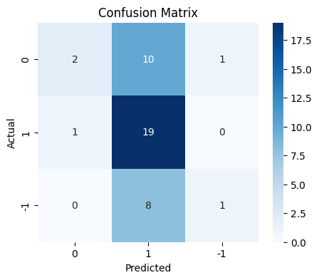

```python
final_model = tuned_st #Select the final model here
X_testfm = X_test_st #Select the test data here
plot_confusion_matrix(final_model,X_testfm,y_test)
```

```python
#Calculating different metrics on training data
final_model_test = model_performance_classification_sklearn(final_model,X_testfm,y_test)
print("Test performance for the final model:\n",final_model_test)
```

[output not shown]

Observations:

- The test performance with the chosen final model, which was the tuned Sentance Transformer, leaves much to be desired.
- Further tuning of the hyperparameters in addition to potential further training would be needed to further improve performance to an acceptable level

## **Weekly News Summarization**

**Important Note**: It is recommended to run this section of the project independently from the previous sections in order to avoid runtime crashes due to RAM overload.

#### Installing and Importing the necessary libraries

```python
# Installation for GPU llama-cpp-python
# uncomment and run the following code in case GPU is being used
# !CMAKE_ARGS="-DLLAMA_CUBLAS=on" FORCE_CMAKE=1 pip install llama-cpp-python -q

# Installation for CPU llama-cpp-python
# uncomment and run the following code in case GPU is not being used
!CMAKE_ARGS="-DLLAMA_CUBLAS=off" FORCE_CMAKE=1 pip install llama-cpp-python -q
```

```
     ━━━━━━━━━━━━━━━━━━━━━━━━━━━━━━━━━━━━━━━━ 66.7/66.7 MB 19.5 MB/s eta 0:00:00
  Installing build dependencies ... done
  Getting requirements to build wheel ... done
  Installing backend dependencies ... done
  Preparing metadata (pyproject.toml) ... done
   ━━━━━━━━━━━━━━━━━━━━━━━━━━━━━━━━━━━━━━━━ 45.5/45.5 kB 4.4 MB/s eta 0:00:00
```

```python
# Function to download the model from the Hugging Face model hub
from huggingface_hub import hf_hub_download
from llama_cpp import Llama # Importing the Llama class from the llama_cpp module

# Importing the library for data manipulation
import pandas as pd
from tqdm import tqdm # For progress bar related functionalities
tqdm.pandas()
```

#### Loading the data

```python
#Define file path to read from and create dataframe to work with
file_path = '/content/drive/My Drive/ColabNotebooks/stock_news.csv'
stock_news = pd.read_csv(file_path)
```

```python
#Create a copy of the data
data = stock_news.copy()
```

#### Loading the model

```python
# #Designating the path and the name of the model to choose
model_name_or_path = "TheBloke/Mistral-7B-Instruct-v0.2-GGUF"
model_basename = "mistral-7b-instruct-v0.2.Q6_K.gguf"

#Did not use this model as it did not perform as well
# model_name_or_path = "TheBloke/Llama-2-13B-chat-GGUF"
# model_basename = "llama-2-13b-chat.Q5_K_M.gguf" # the model is in gguf format

model_path = hf_hub_download(
    repo_id = model_name_or_path,
    filename = model_basename
)
```

```python
# # Uncomment the below snippet of code if the runtime is connected to GPU.
llm = Llama(
    model_path=model_path, # Path to the model
    n_gpu_layers=100, # Number of layers transferred to GPU
    n_ctx=5000, # Context window
)
```

[output not shown]

[output cut: 117 more lines]

[output not shown]

```python
# uncomment and run the following code in case GPU is not being used

# llm = Llama(
#     model_path=model_path,
#     n_ctx=4500, # Context window
#     n_threads=-2 # Number of CPU cores to use; USE TERM THREADS as cores is not recognized
# )
```

#### Aggregating the data weekly

```python
# Convert the 'Date' column to datetime format.
data["Date"] = pd.to_datetime(data['Date'])
```

```python
# Group the data by week using the 'Date' column.
weekly_grouped = data.groupby(pd.Grouper(key='Date', freq='W'))
```

```python
# Regroup the weekly data line by line by date column first followed by news column
weekly_grouped = weekly_grouped.agg({'News': lambda x: ' || '.join(x)}).reset_index()
print(weekly_grouped.shape)
weekly_grouped
```

```
(18, 2)
```

|  | Date | News |
| --- | --- | --- |
| 0 | 2019-01-06 | The tech sector experienced a significant dec... |
| 1 | 2019-01-13 | Sprint and Samsung plan to release 5G smartph... |
| 2 | 2019-01-20 | The U.S. stock market declined on Monday as c... |
| 3 | 2019-01-27 | The Swiss National Bank (SNB) governor, Andre... |
| 4 | 2019-02-03 | Caterpillar Inc reported lower-than-expected ... |
| 5 | 2019-02-10 | The Dow Jones Industrial Average, S&P 500, an... |
| 6 | 2019-02-17 | This week, the European Union's second highes... |
| 7 | 2019-02-24 | This news article discusses progress towards ... |
| 8 | 2019-03-03 | The Dow Jones Industrial Average and other ma... |
| 9 | 2019-03-10 | Spotify, the world's largest paid music strea... |
| 10 | 2019-03-17 | The United States opposes France's digital se... |
| 11 | 2019-03-24 | Facebook's stock price dropped more than 3% o... |
| 12 | 2019-03-31 | This news article reports that the S&P 500 In... |
| 13 | 2019-04-07 | Apple and other consumer brands, including LV... |
| 14 | 2019-04-14 | In March, mobile phone shipments to China dro... |
| 15 | 2019-04-21 | The chairman of Taiwan's Foxconn, Terry Gou, ... |
| 16 | 2019-04-28 | Taiwan's export orders continued to decline f... |
| 17 | 2019-05-05 | Spotify reported better-than-expected Q1 reve... |

```python
# Creating a copy of the weekly grouped data
data1 = weekly_grouped.copy()
print(data1)
```

```
         Date                                               News
0  2019-01-06   The tech sector experienced a significant dec...
1  2019-01-13   Sprint and Samsung plan to release 5G smartph...
2  2019-01-20   The U.S. stock market declined on Monday as c...
3  2019-01-27   The Swiss National Bank (SNB) governor, Andre...
4  2019-02-03   Caterpillar Inc reported lower-than-expected ...
5  2019-02-10   The Dow Jones Industrial Average, S&P 500, an...
6  2019-02-17   This week, the European Union's second highes...
7  2019-02-24   This news article discusses progress towards ...
8  2019-03-03   The Dow Jones Industrial Average and other ma...
9  2019-03-10   Spotify, the world's largest paid music strea...
10 2019-03-17   The United States opposes France's digital se...
11 2019-03-24   Facebook's stock price dropped more than 3% o...
12 2019-03-31   This news article reports that the S&P 500 In...
13 2019-04-07   Apple and other consumer brands, including LV...
14 2019-04-14   In March, mobile phone shipments to China dro...
15 2019-04-21   The chairman of Taiwan's Foxconn, Terry Gou, ...
16 2019-04-28   Taiwan's export orders continued to decline f...
17 2019-05-05   Spotify reported better-than-expected Q1 reve...
```

#### Summarization

##### Utility Functions

```python
# defining a function to parse the JSON output from the model
def extract_json_data(json_str):
    import json
    try:
        # Find the indices of the opening and closing curly braces
        json_start = json_str.find('{')
        json_end = json_str.rfind('}')

        if json_start != -1 and json_end != -1:
            extracted_category = json_str[json_start:json_end + 1]  # Extract the JSON object
            data_dict = json.loads(extracted_category)
            return data_dict
        else:
            print(f"Warning: JSON object not found in response: {json_str}")
            return {}
    except json.JSONDecodeError as e:
        print(f"Error parsing JSON: {e}")
        return {}
```

##### Defining the response function

```python
#Defining the response function
def response_llm_1(prompt, news):
    model_output = llm(
      f"""
      [INST]
      {prompt}
      News Articles: {news}
      [/INST]
      """,
      max_tokens=800, #to set the maximum number of tokens the model should generate for this task.
      temperature=0.1, #to set the value for temperature.
      top_p=0.7, #to set the value for top_p
      top_k=25, #to set the value for top_k
      echo=False,
    )

    final_output = model_output["choices"][0]["text"]

    return final_output
```

```python
# Create a new array with all the news contained within as a string
news = data1.loc[0, 'News']
print(news)
print(len(news.split(' ')))
```

```
 The tech sector experienced a significant decline in the aftermarket following Apple's Q1 revenue warning. Notable suppliers, including Skyworks, Broadcom, Lumentum, Qorvo, and TSMC, saw their stocks drop in response to Apple's downward revision of its revenue expectations for the quarter, previous…
2611
```

```python
#Define the prompt for the LLM to be ran with

prompt = """
You are an AI-powered sentiment analysis assistant tasked with summarizing weekly news for a NASDAQ-listed company. Your analysis will help financial analysts understand market sentiment by identifying key news events that may impact the company's stock price.

Business Context:
The stock prices of companies listed under a global exchange are influenced by various factors, including the company's financial performance, innovations, collaborations, and overall market sentiment. News and media reports can rapidly shift investor perceptions, which in turn affects stock prices. With the overwhelming volume of news and diverse opinions, investors and financial analysts need sophisticated tools to filter and interpret relevant events accurately.

"instructions":

Task:
- Analyze the daily news articles from each week.
    "Identify the top three positive and top three negative events that are most likely to influence the stock price. Consider factors like financial performance, innovations, partnerships, market sentiment, and industry trends."
   Please generate this as a JSON based on the weekly news data.
   Only 2 keys should be generated as shown below

   #Example Output Structure:

     "Positive Events':
     ["Positive event 1",
       "Positive event 2",
       "Positive event 3"
     ]

     "Negative Events":
     ["Negative event 1",
      "Negative event 2",
       "Negative event 3"
     ]
   }
   }

# """
```

##### Checking the model output on a sample

**Note**: Use this section to test out the prompt with one instance before using it for the entire weekly data.

```python
%%time
#Creates a Summary of what is produced by the model for one instance
summary = response_llm_1(prompt, news)
print(summary)
```

```
llama_perf_context_print:        load time =  165735.48 ms
llama_perf_context_print: prompt eval time =  165734.99 ms /  4087 tokens (   40.55 ms per token,    24.66 tokens per second)
llama_perf_context_print:        eval time =   20766.88 ms /   225 runs   (   92.30 ms per token,    10.83 tokens per second)
llama_perf_context_print:       total time =  186608.76 ms /  4312 tokens
```

```
 {
         "Positive Events": [
           "Roku Inc announces plans to offer premium video channels on a subscription basis through its free streaming service, The Roku Channel",
           "FDIC Chair Jelena McWilliams expresses no concern over market volatility affecting the U.S banking system",
           "Chinese central bank announces a fifth reduction in the required reserve ratio (RRR) for banks, freeing up approximately 116.5 billion yuan for new lending"
         ],

         "Negative Events": [
           "Apple cuts its quarterly revenue forecast for the first time in over 15 years due to weak iPhone sales in China",
           "Investors withdrew a record $98 billion from U.S stock funds in December due to fears of aggressive monetary policy and an economic slowdown",
           "Apple's profit warning leads to significant losses for Berkshire Hathaway due to its $252 million stake in Apple"
         ]
       }
CPU times: user 1h 7min 42s, sys: 14.7 s, total: 1h 7min 56s
Wall time: 3min 6s
```

##### Generating the Key Events column in the dataframe using the LLM

```python
#Generate the output for the model to be called as Key Events within the data frame
#Check the values and shape of the dataframe before and after the model is ran
%%time
print(data1)
print(data1.shape)
data1['Key Events'] = data1['News'].progress_apply(lambda x: response_llm_1(prompt,x))
print(data1)
print(data1.shape)
```

```
         Date                                               News
0  2019-01-06   The tech sector experienced a significant dec...
1  2019-01-13   Sprint and Samsung plan to release 5G smartph...
2  2019-01-20   The U.S. stock market declined on Monday as c...
3  2019-01-27   The Swiss National Bank (SNB) governor, Andre...
4  2019-02-03   Caterpillar Inc reported lower-than-expected ...
5  2019-02-10   The Dow Jones Industrial Average, S&P 500, an...
6  2019-02-17   This week, the European Union's second highes...
7  2019-02-24   This news article discusses progress towards ...
8  2019-03-03   The Dow Jones Industrial Average and other ma...
9  2019-03-10   Spotify, the world's largest paid music strea...
10 2019-03-17   The United States opposes France's digital se...
11 2019-03-24   Facebook's stock price dropped more than 3% o...
12 2019-03-31   This news article reports that the S&P 500 In...
13 2019-04-07   Apple and other consumer brands, including LV...
14 2019-04-14   In March, mobile phone shipments to China dro...
15 2019-04-21   The chairman of Taiwan's Foxconn, Terry Gou, ...
16 2019-04-28   Taiwan's export orders continued to decline f...
17 2019-05-05   Spotify reported better-than-expected Q1 reve...
(18, 2)
```

[output not shown]

[output cut: 17 more lines]

[output not shown]

```
         Date                                               News  \
0  2019-01-06   The tech sector experienced a significant dec...
1  2019-01-13   Sprint and Samsung plan to release 5G smartph...
2  2019-01-20   The U.S. stock market declined on Monday as c...
3  2019-01-27   The Swiss National Bank (SNB) governor, Andre...
4  2019-02-03   Caterpillar Inc reported lower-than-expected ...
5  2019-02-10   The Dow Jones Industrial Average, S&P 500, an...
6  2019-02-17   This week, the European Union's second highes...
7  2019-02-24   This news article discusses progress towards ...
8  2019-03-03   The Dow Jones Industrial Average and other ma...
9  2019-03-10   Spotify, the world's largest paid music strea...
10 2019-03-17   The United States opposes France's digital se...
11 2019-03-24   Facebook's stock price dropped more than 3% o...
12 2019-03-31   This news article reports that the S&P 500 In...
13 2019-04-07   Apple and other consumer brands, including LV...
```

[output cut: 27 more lines]

```python
#Print the dataframe, shap and what the Key Events Column head looks like
print(data1)
print(data1.shape)
data1["Key Events"].head()
```

```
         Date                                               News  \
0  2019-01-06   The tech sector experienced a significant dec...
1  2019-01-13   Sprint and Samsung plan to release 5G smartph...
2  2019-01-20   The U.S. stock market declined on Monday as c...
3  2019-01-27   The Swiss National Bank (SNB) governor, Andre...
4  2019-02-03   Caterpillar Inc reported lower-than-expected ...
5  2019-02-10   The Dow Jones Industrial Average, S&P 500, an...
6  2019-02-17   This week, the European Union's second highes...
7  2019-02-24   This news article discusses progress towards ...
8  2019-03-03   The Dow Jones Industrial Average and other ma...
9  2019-03-10   Spotify, the world's largest paid music strea...
10 2019-03-17   The United States opposes France's digital se...
11 2019-03-24   Facebook's stock price dropped more than 3% o...
12 2019-03-31   This news article reports that the S&P 500 In...
13 2019-04-07   Apple and other consumer brands, including LV...
```

[output cut: 25 more lines]

|  | Key Events |
| --- | --- |
| 0 | {\n "Positive Events": [\n ... |
| 1 | {\n "Positive Events": [\n ... |
| 2 | {\n "Positive Events": [\n ... |
| 3 | {\n "Positive Events": [\n ... |
| 4 | {\n "Positive Events": [\n ... |

**dtype:** object

```python
#Complete check of Key Events column, output from LLM, to see if output meets JSON format
import json
sample = data1['Key Events'].iloc[0]
try:
    json_obj = json.loads(sample)
    print("Valid JSON:", json_obj)
except Exception as e:
    print("Error parsing JSON:", e)
```

```
Valid JSON: {'Positive Events': ['Roku Inc announces plans to offer premium video channels on a subscription basis through its free streaming service, The Roku Channel.', 'FDIC Chair Jelena McWilliams expresses no concern over market volatility affecting the U.S banking system.', 'Chinese central ba…
```

```python
#Extract only the JSON data from the Key Events data and put it another column dubbed Model Response
#Check what the dataframe now looks like with this new data column
data1['model_response'] = data1['Key Events'].apply(extract_json_data)
print(data1.head())
print(data1)
```

```
        Date                                               News  \
0 2019-01-06   The tech sector experienced a significant dec...
1 2019-01-13   Sprint and Samsung plan to release 5G smartph...
2 2019-01-20   The U.S. stock market declined on Monday as c...
3 2019-01-27   The Swiss National Bank (SNB) governor, Andre...
4 2019-02-03   Caterpillar Inc reported lower-than-expected ...

                                          Key Events  \
0   {\n         "Positive Events": [\n           ...
1   {\n         "Positive Events": [\n           ...
2   {\n         "Positive Events": [\n           ...
3   {\n         "Positive Events": [\n           ...
4   {\n         "Positive Events": [\n           ...

                                      model_response
```

[output cut: 64 more lines]

```python
#Normalize the data within the model response column and generate a new dataframe called model response
#Review the data within this dataframe
model_response = pd.json_normalize(data1['model_response'])
model_response.head()
print(model_response)
```

```
                                      Positive Events  \
0   [Roku Inc announces plans to offer premium vid...
1   [Sprint and Samsung's plan to release 5G smart...
2   [Dialog Semiconductor reported fourth quarter ...
3   [IBM's stock price increased after hours due t...
4   [Apple reported stronger-than-expected earning...
5   [JPMorgan suggests Apple should acquire Netfli...
6   [Apple reported stronger than projected earnin...
7   [Garmin reported stronger-than-expected fourth...
8   [President Trump announced progress in trade t...
9   [Spotify reported over 1 million unique users ...
10  [Apple launched a new television advertising c...
11  [Foxconn announces completion of new factory i...
12  [Apple's new television and movie streaming se...
13  [Apple and other consumer brands, including LV...
```

[output cut: 24 more lines]

```python
#Print the final output dataframe by adding the model response to the data1 dataframe
#Review the final shape of the final output and the model response dataframes
#Drop the columns of Key Events and model response
#Clarify the columns of Week End Date, News, Week Positive Events, and Week Negative Events for the final dataframe output
final_output = pd.concat([data1.reset_index(drop=True),model_response],axis=1)
print(final_output)
print(final_output.shape)
print(model_response)
print(model_response.shape)

final_output.drop(['Key Events','model_response'], axis=1, inplace=True)
print(final_output.head())
final_output.columns = ['Week End Date', 'News', 'Week Positive Events', 'Week Negative Events']
print(final_output.head())
final_output
```

```
         Date                                               News  \
0  2019-01-06   The tech sector experienced a significant dec...
1  2019-01-13   Sprint and Samsung plan to release 5G smartph...
2  2019-01-20   The U.S. stock market declined on Monday as c...
3  2019-01-27   The Swiss National Bank (SNB) governor, Andre...
4  2019-02-03   Caterpillar Inc reported lower-than-expected ...
5  2019-02-10   The Dow Jones Industrial Average, S&P 500, an...
6  2019-02-17   This week, the European Union's second highes...
7  2019-02-24   This news article discusses progress towards ...
8  2019-03-03   The Dow Jones Industrial Average and other ma...
9  2019-03-10   Spotify, the world's largest paid music strea...
10 2019-03-17   The United States opposes France's digital se...
11 2019-03-24   Facebook's stock price dropped more than 3% o...
12 2019-03-31   This news article reports that the S&P 500 In...
13 2019-04-07   Apple and other consumer brands, including LV...
```

[output cut: 165 more lines]

|  | Week End Date | News | Week Positive Events | Week Negative Events |
| --- | --- | --- | --- | --- |
| 0 | 2019-01-06 | The tech sector experienced a significant dec... | [Roku Inc announces plans to offer premium vid... | [Apple cuts its quarterly revenue forecast for... |
| 1 | 2019-01-13 | Sprint and Samsung plan to release 5G smartph... | [Sprint and Samsung's plan to release 5G smart... | [Geely's forecast of flat sales for 2019 due t... |
| 2 | 2019-01-20 | The U.S. stock market declined on Monday as c... | [Dialog Semiconductor reported fourth quarter ... | [The U.S. stock market declined on Monday as c... |
| 3 | 2019-01-27 | The Swiss National Bank (SNB) governor, Andre... | [IBM's stock price increased after hours due t... | [The Swiss National Bank (SNB) governor, Andre... |
| 4 | 2019-02-03 | Caterpillar Inc reported lower-than-expected ... | [Apple reported stronger-than-expected earning... | [Caterpillar Inc reported lower-than-expected ... |
| 5 | 2019-02-10 | The Dow Jones Industrial Average, S&P 500, an... | [JPMorgan suggests Apple should acquire Netfli... | [Despite strong January market performance, fe... |
| 6 | 2019-02-17 | This week, the European Union's second highes... | [Apple reported stronger than projected earnin... | [The European Union's second highest court wil... |
| 7 | 2019-02-24 | This news article discusses progress towards ... | [Garmin reported stronger-than-expected fourth... | [Kraft Heinz suffered a significant loss in pr... |
| 8 | 2019-03-03 | The Dow Jones Industrial Average and other ma... | [President Trump announced progress in trade t... | [AAC Technologies Holdings reported a signific... |
| 9 | 2019-03-10 | Spotify, the world's largest paid music strea... | [Spotify reported over 1 million unique users ... | [Mozilla considering revoking DarkMatter's aut... |
| 10 | 2019-03-17 | The United States opposes France's digital se... | [Apple launched a new television advertising c... | [The United States opposes France's digital se... |
| 11 | 2019-03-24 | Facebook's stock price dropped more than 3% o... | [Foxconn announces completion of new factory i... | [Facebook's stock price drops more than 3% fol... |
| 12 | 2019-03-31 | This news article reports that the S&P 500 In... | [Apple's new television and movie streaming se... | [The S&P 500 and Dow Jones Industrial Average ... |
| 13 | 2019-04-07 | Apple and other consumer brands, including LV... | [Apple and other consumer brands, including LV... | [Apple suffered pre-market losses after a soft... |
| 14 | 2019-04-14 | In March, mobile phone shipments to China dro... | [Apple's Q1 earnings surpassed expectations, l... | [Mobile phone shipments to China dropped by 6 ... |
| 15 | 2019-04-21 | The chairman of Taiwan's Foxconn, Terry Gou, ... | [TomTom reported a 14% increase in first quart... | [Apple faced a securities fraud lawsuit for al... |
| 16 | 2019-04-28 | Taiwan's export orders continued to decline f... | [Chinese tech giant Tencent Holdings invested ... | [Taiwan's export orders continued to decline f... |
| 17 | 2019-05-05 | Spotify reported better-than-expected Q1 reve... | [Spotify reported better-than-expected Q1 reve... | [Czech Finance Ministry is finalizing plans to... |

## **Conclusions and Recommendations**

- I used an LLM to do multiple tasks for the NLP Project:
  1. Asked it to summarize all market news article from the data by week published
  2. Associate the News Articles with either a positive or negative sentiment in terms of effects on company market shares
  3. Find the top 3 positive and top 3 negative news articles for each week most likely to affect company market shares
  4. Produce these top 3 positive and top 3 negative events for each week in an output dataframe in JSON format
- To try and improve the model output, one can try the following:
  1. Update/Edit the prompt
  2. Update/Edit the model parameters (temperature, top_p, top_k, etc.)

# Convert to HTML

```python
!pip install nbconvert
```

```python
!jupyter nbconvert --to html '/content/drive/My Drive/ColabNotebooks/NLP_Project_Full_Code-JRW.ipynb'
```

[output not shown]

[output cut: 54 more lines]

[output not shown]